# Home assignment 2

Author

Vincent PLATEAU

```r
knitr::opts_chunk$set(warning = FALSE, message = FALSE)
```

Packages needed :

```r
library(tidyverse)
library(dplyr)
library(RSQLite)
library(dataMaid)
library(readr)
```

# Import “bi_product.txt” and “bi_salesFact.txt”. And join tables on **ProductID**.

```r
# Import bi_product.txt and bi_salesFact.txt
product_data <- read_delim("bi_product.txt", delim = ";")
sales_data <- read_delim("bi_sales.txt", delim = ",")
```

```r
# Join on ProductID
merged_data <- left_join(sales_data, product_data, by = "ProductID")
```

# Use dataMaid package to describe the data

**Note**

It doesn’t work when you render this part, so I let a “#” here.

```r
#makeDataReport(merged_data)
```

# Quick description of the data

```r
summary(merged_data)
```

```
   ProductID         zip            Units           Revenue
 Min.   :   1   Min.   :10002   Min.   : 1.000   Min.   :   34.07
 1st Qu.: 549   1st Qu.:32812   1st Qu.: 1.000   1st Qu.:  293.95
 Median : 945   Median :55113   Median : 1.000   Median :  514.45
 Mean   :1141   Mean   :56544   Mean   : 1.031   Mean   :  617.88
 3rd Qu.:1850   3rd Qu.:80515   3rd Qu.: 1.000   3rd Qu.:  892.45
 Max.   :2412   Max.   :99901   Max.   :26.000   Max.   :10300.03
                                                 NA's   :3
    Datekey             city              state              latitude
 Min.   :20100104   Length:20355       Length:20355       Min.   :24.57
 1st Qu.:20110523   Class :character   Class :character   1st Qu.:33.75
 Median :20121006   Mode  :character   Mode  :character   Median :38.19
 Mean   :20123976                                         Mean   :37.62
 3rd Qu.:20140410                                         3rd Qu.:41.27
 Max.   :20150630                                         Max.   :71.30

   longitude         Product            Category           Segment
 Min.   :-161.88   Length:20355       Length:20355       Length:20355
 1st Qu.:-105.31   Class :character   Class :character   Class :character
 Median : -89.84   Mode  :character   Mode  :character   Mode  :character
 Mean   : -94.32
 3rd Qu.: -81.75
 Max.   : -72.19

 ManufacturerID
 Min.   : 1.000
 1st Qu.: 4.000
 Median : 7.000
 Mean   : 6.898
 3rd Qu.: 8.000
 Max.   :14.000
```

Based on the report and the summary we can emphasize some interesting points :

1. There is 2412 different products and 4 categories (mix, urban, rural and Youth)
2. The most popular category is “urban”:

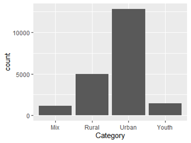

3. The best-selling product is “Maximus UM-54” with 625 sales.

```r
count_bestsale <- merged_data %>%
  filter(Product == "Maximus UM-54") %>%
  nrow()

print(count_bestsale)
```

```
[1] 625
```

This graph shows how many times each products were sold.

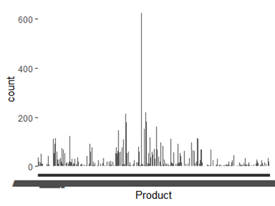

4. Geographically, California seems to be the state where most sales are made.

# Show the sum of units and revenue for every product category

**Small issue**

I didn’t made this part with RSQLite because it wasn’t mentionned in the exercise description. I realized at the end that I could have done this part with RSQLite.

Sum of units for every product category:

```r
SumUnitsperCateg<- merged_data %>%
  group_by(Category) %>%
  summarise(total_units = sum(Units))

print(SumUnitsperCateg)
```

```
# A tibble: 4 × 2
  Category total_units
  <chr>          <dbl>
1 Mix             1179
2 Rural           5215
3 Urban          13121
4 Youth           1480
```

Sum of revenue for every product category:

**Note**

For this point, I realized that there were NAs in the Revenue column. So I’ve replaced it by 0.

```r
summary(merged_data$Revenue)
```

```
    Min.  1st Qu.   Median     Mean  3rd Qu.     Max.     NA's
   34.07   293.95   514.45   617.88   892.45 10300.03        3
```

```r
# Replace NA by 0
merged_data$Revenue[is.na(merged_data$Revenue)] <- 0
summary(merged_data$Revenue)
```

```
   Min. 1st Qu.  Median    Mean 3rd Qu.    Max.
    0.0   293.9   514.4   617.8   892.4 10300.0
```

```r
SumRevperCateg <- merged_data %>%
  group_by(Category) %>%
  summarise(total_revenue = sum(`Revenue`))

print(SumRevperCateg)
```

```
# A tibble: 4 × 2
  Category total_revenue
  <chr>            <dbl>
1 Mix            505444.
2 Rural         1307780.
3 Urban        10487380.
4 Youth          274469.
```

# Which is the cheapest product and which is the most expensive one?

**Note**

For this question I’ve used RSQLite.

Let’s create a SQLite database:

```r
conn <- dbConnect(RSQLite::SQLite(), dbname = "merged_data.db")

# Write the merged_data dataset into a table names merged_data
dbWriteTable(conn, "merged_data", merged_data, overwrite = TRUE)
```

The cheapest product is Pirum RP-30:

```r
# RSQLite query to get the cheapest product

dbGetQuery(conn, "
  SELECT Product, MIN(Revenue / Units) AS Unit_Price
  FROM merged_data
  WHERE Revenue / Units != 0") # Here I've added this condition to get the cheapest product but with a price different from 0
```

```
      Product Unit_Price
1 Pirum RP-30    34.0725
```

The most expansive product is Fama UE-68.

```r
# RSQLite query to get the most expansive product
dbGetQuery(conn, "
                  SELECT Product, MAX(Revenue / Units) AS Unit_Price
                  FROM merged_data")
```

```
     Product Unit_Price
1 Fama UE-68     3412.5
```

# With tidyverse show the best 3 Categories by revenue and in each selected category the 3 best products

First let’s compute the revenue for each categories (we already did it previously) :

```r
category_revenue <- merged_data %>%
  group_by(Category) %>%
  summarise(Total_Revenue = sum(Revenue, na.rm = TRUE)) %>%
  arrange(desc(Total_Revenue)) %>%
 slice_max(Total_Revenue, n = 3) # TOP 3

print(category_revenue)
```

```
# A tibble: 3 × 2
  Category Total_Revenue
  <chr>            <dbl>
1 Urban        10487380.
2 Rural         1307780.
3 Mix            505444.
```

Then, we’ll show best 3 products for each categories of these 3 categories:

```r
top_products <- merged_data %>%
  filter(Category %in% category_revenue$Category) %>%
  group_by(Category, Product) %>%
  summarise(Total_Revenue = sum(Revenue)) %>%
  arrange(Category, desc(Total_Revenue)) %>%
  group_by(Category) %>%
  slice_max(Total_Revenue, n = 3)

top_products
```

```
# A tibble: 9 × 3
# Groups:   Category [3]
  Category Product       Total_Revenue
  <chr>    <chr>                 <dbl>
1 Mix      Pirum MA-11          47448.
2 Mix      Abbas MA-26          41118
3 Mix      Abbas MA-03          33865.
4 Rural    Aliqui RS-08         72275.
5 Rural    Aliqui RS-02         61350.
6 Rural    Natura RP-22         52268.
7 Urban    Maximus UM-11       718517.
8 Urban    Maximus UM-54       671407.
9 Urban    Maximus UM-12       442853.
```

# What are the mean and median (Revenue) of every category?

We can easily compute the mean with a SQLite query:

```r
dbGetQuery(conn,"SELECT Category, AVG(Revenue) AS Mean_Revenue
FROM merged_data
GROUP BY Category")
```

```
  Category Mean_Revenue
1      Mix     441.0502
2    Rural     263.7185
3    Urban     817.6657
4    Youth     192.7453
```

```r
# Close the connection after use
dbDisconnect(conn)
```

But tidyverse is more efficient to compute both quickly:

```r
medandmean <- merged_data %>%
  group_by(Category) %>%
  summarise(
    Mean_Revenue = mean(Revenue, na.rm = TRUE),
    Median_Revenue = median(Revenue, na.rm = TRUE))

medandmean
```

```
# A tibble: 4 × 3
  Category Mean_Revenue Median_Revenue
  <chr>           <dbl>          <dbl>
1 Mix              441.           362.
2 Rural            264.           205.
3 Urban            818.           782.
4 Youth            193.           152.
```

# Two charts using ggplot2

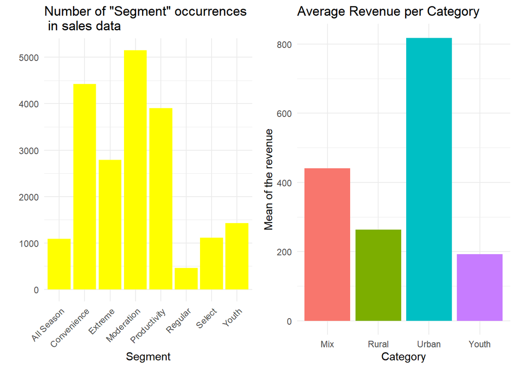

```r
library(ggplot2)
library(gridExtra)

# For the first diagram, I want to measure the popularity of each segment
segment_counts <- merged_data %>%
  group_by(Segment) %>%
  summarise(Count = n())

p1 <- ggplot(segment_counts, aes(x = Segment, y = Count)) +
  geom_bar(stat = "identity", fill = "yellow") +
  theme_minimal() +
  labs(title = 'Number of "Segment" occurrences \n in sales data', x = "Segment", y = "") +
  theme(axis.text.x = element_text(angle = 45, hjust = 1))


# For the 2nd diagram : mean of revenues for each category
p2 <- medandmean %>%
  ggplot(aes(x = Category, y = Mean_Revenue, fill = Category)) +
  geom_bar(stat = "identity") +
  theme_minimal() +
  labs(title = "Average Revenue per Category", x = "Category", y = "Mean of the revenue") +
  theme(legend.position = "none")

# 2 charts side by side
grid.arrange(p1, p2, ncol = 2)
```

On the left, we can see a histogram showing the popularity of each segment. It is based on the number of sales (sales_data). We can conclude that the Moderation, Convenience and Productivity segments generate the most sales. The segments : Regular, Select and All Season don’t have many sales, a weakness that needs to be improved.

On the right, the histogram of average revenues by category. On average, the Urban category generates the most revenue, but the Youth category the least.

# Explain which approach (tidyverse or RSQLite do you prefer and why)

I prefer the Tidyverse package, for its many features and also because it’s easy to use most of the time. However, I recognize that RSQLite can be useful because it allows you to have the advantages of SQLite in an R environment.

# Take TA_reviews.xlsx file and calculate the average sentiment by yearmonth

```r
library(readxl)
library(dplyr)
library(tidyr)
library(tidytext)

# Read data
reviews <- read_excel("TA_reviews.xlsx")

# Extract Year-Month from date
reviews <- reviews %>%
  mutate(yearmonth = format(as.Date(date), "%Y-%m"))

# Unnest words from fullrev column
tidy_reviews <- reviews %>%
  unnest_tokens(word, fullrev)

# Calculate sentiment score using tidytext's sentiments dataset
sentiment_scores <- tidy_reviews %>%
  inner_join(get_sentiments("bing")) %>% # bing = positive or negative (not nrc)
  count(id, index = yearmonth, sentiment) %>%
  spread(sentiment, n, fill = 0) %>%
  mutate(sentiment_score = positive - negative)

# Calculate average sentiment score by Year-Month
average_sentiment <- sentiment_scores %>%
  group_by(index) %>%
  summarise(avg_sentiment = mean(sentiment_score))
```

As you can see the sentiment score is calculated by doing: number of positive words - number of negative words (detected by get_sentiments(“bing”)).

```r
head(sentiment_scores)
```

```
# A tibble: 6 × 5
         id index   negative positive sentiment_score
      <dbl> <chr>      <dbl>    <dbl>           <dbl>
1 152388526 2013-02        0        9               9
2 153020500 2013-02        4       15              11
3 153236190 2013-02        1        6               5
4 153260706 2013-02        2       10               8
5 153586174 2013-03        0       12              12
6 155094521 2013-03        0       10              10
```

At the end, this table shows an average sentiment score for each month from February 2013 to May 2018:

```r
average_sentiment
```

```
# A tibble: 64 × 2
   index   avg_sentiment
   <chr>           <dbl>
 1 2013-02          8.25
 2 2013-03          8.75
 3 2013-04          7.25
 4 2013-05         12.7
 5 2013-06          8.57
 6 2013-07          7
 7 2013-08          8.33
 8 2013-09          7.12
 9 2013-10          4.73
10 2013-11          6
# ℹ 54 more rows
```

We can do the exact same process but only for year:

```r
# Extract Year-Month from date
reviews <- reviews %>%
  mutate(yearmonth = format(as.Date(date), "%Y"))

# Unnest words from fullrev column
tidy_reviews <- reviews %>%
  unnest_tokens(word, fullrev)

# Calculate sentiment score using tidytext's sentiments dataset
sentiment_scores <- tidy_reviews %>%
  inner_join(get_sentiments("bing")) %>% # bing = positive or negative (not nrc)
  count(id, index = yearmonth, sentiment) %>%
  spread(sentiment, n, fill = 0) %>%
  mutate(sentiment_score = positive - negative)

# Calculate average sentiment score by Year-Month
average_sentiment <- sentiment_scores %>%
  group_by(index) %>%
  summarise(avg_sentiment = mean(sentiment_score))

average_sentiment <- average_sentiment %>% arrange(desc(avg_sentiment))
average_sentiment
```

```
# A tibble: 6 × 2
  index avg_sentiment
  <chr>         <dbl>
1 2013           7.15
2 2017           6.77
3 2015           6.44
4 2016           6.19
5 2014           5.84
6 2018           5.82
```

The Year 2013 was the one with the most positive reviews on TripAdvisor for this hotel.

```
                               **THANK YOU**
```